# Climate Data Analysis - filtered symptom response

Joey Hulbert

5/29/2022

# Purpose

The purpose of this markdown document is to list the steps we followed for refining the models using climate data only.

# Data

The data used in the below models are described in the Data Wrangle folder.

## Response variables

**Note the below analysis uses the iNat data with 1510 observations. Amazing!**

Below we compare models using canopy symptoms as the response variable

## Explanatory variables

- Explanatory variables included
  - Climate data
    - 30yr normals 1991-2020 (265 variables - annual, seasonal, monthly)

> Note that we included na.string=“-9999” when reading data.

# Data wrangling

There are multiple methods to group the response variables deepening on desired resolution or fineness of the model.

All tree health categories

```
## # A tibble: 12 × 2
## # Groups:   field.tree.canopy.symptoms [12]
##    field.tree.canopy.symptoms                             n
##    <fct>                                              <int>
##  1 Branch Dieback or 'Flagging'                          74
##  2 Browning Canopy                                       43
##  3 Candelabra top or very old spike top (old growth)      2
##  4 Extra Cone Crop                                        4
##  5 Healthy                                              813
##  6 Multiple Symptoms (please list in Notes)              31
##  7 New Dead Top (red or brown needles still attached)    48
##  8 Old Dead Top (needles already gone)                  154
##  9 Other (please describe in Notes)                      16
## 10 Thinning Canopy                                      225
## 11 Tree is dead                                          74
## 12 Yellowing Canopy                                      26
```

We also need to filter the data to only include response and explanatory variables we’re interested in. For example, whether a sound clip was included in the iNat data is not important.

We also need to remove other response variables like “field.percent.canopy.affected….” so it is not used as a predictor for tree health.

> Note it might be interesting to know if the user was an important factor in predicting if the tree is healthy/unhealthy.

There are also a number of factors that should probably be removed because they may be biasing the data. For example, only trees with the ‘other factor’ question may only be answered for unhealthy trees. We need to think about this a bit more.

First remove iNat factors not useful as explanatory variables (e.g. observed_on)

Then, remove specific climate variables not useful as explanatory variables (e.g. norm_Latitutde)

Remove variables with variables that have near zero standard deviations (entire column is same value)

## Group response variables to filtered symptoms groups

- Reclassified symptoms
  - Here we can created an ‘other’ variable to represent trees with the below symptoms
    - Extra cone crop
    - Yellowing canopy
    - Browning canopy
    - Multiple symptoms
    - Other
    - Branch Dieback or ’Flagging

```
## # A tibble: 5 × 2
## # Groups:   field.tree.canopy.symptoms [5]
##   field.tree.canopy.symptoms     n
##   <fct>                      <int>
## 1 Healthy                      813
## 2 Thinning Canopy              225
## 3 Dead Top                     202
## 4 Tree is Dead                  74
## 5 Other                        194
```

reclassified tree health categories

```
## # A tibble: 5 × 2
## # Groups:   field.tree.canopy.symptoms [5]
##   field.tree.canopy.symptoms     n
##   <fct>                      <int>
## 1 Healthy                      810
## 2 Thinning Canopy              224
## 3 Dead Top                     202
## 4 Tree is Dead                  73
## 5 Other                        194
```

# Approach

- General approach
  - build full model using reclassified response grouping variable
    - reclassified response
  - refine model to remove redundant explanatory variables

# Models

- Random forest model criteria
  - nearzero variation columns were removed
  - Data were imputed prior to model building.
  - number of splits was not defined to allow automatic selection,
  - ntree = 2001, importance = TRUE, proximity = TRUE, na.action = na.omit
  - seed was set for reproducability with: set.seed(71)

## Comparing full and reduced datasets of explanatory variables

### Symptom response variable

#### Normal, Monthless Model

```
##
## Call:
##  randomForest(formula = field.tree.canopy.symptoms ~ ., data = normal.monthless.reclassified,      ntree = 2001, importance = TRUE, proximity = TRUE, na.action = na.omit)
##                Type of random forest: classification
##                      Number of trees: 2001
## No. of variables tried at each split: 8
##
##         OOB estimate of  error rate: 46.24%
## Confusion matrix:
##                 Healthy Thinning Canopy Dead Top Tree is Dead Other class.error
## Healthy             639              49       43           20    59   0.2111111
## Thinning Canopy     107              58       29            7    23   0.7410714
## Dead Top             85              29       56           11    21   0.7227723
## Tree is Dead         30              13       14           11     5   0.8493151
## Other                99              25       20            6    44   0.7731959
```

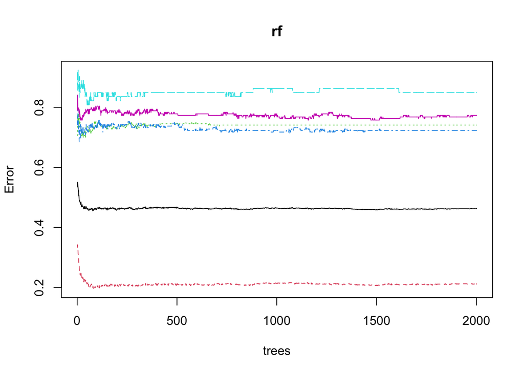

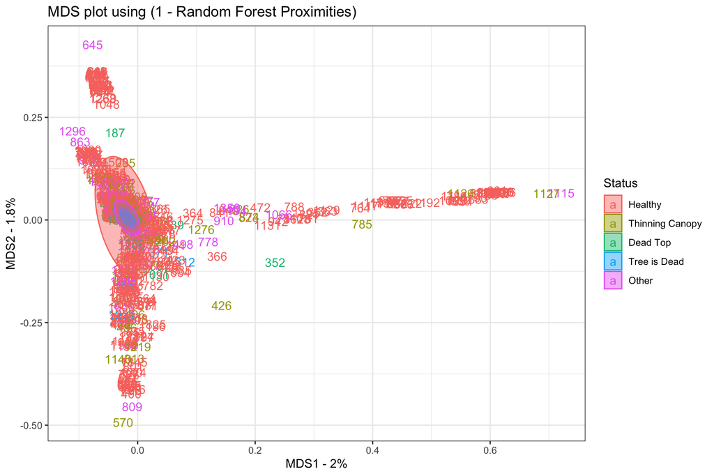

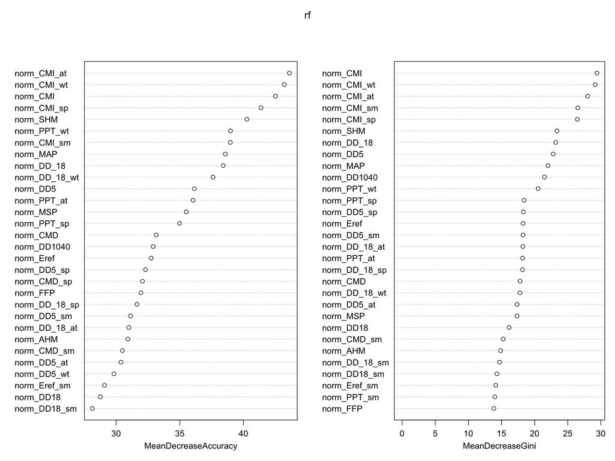

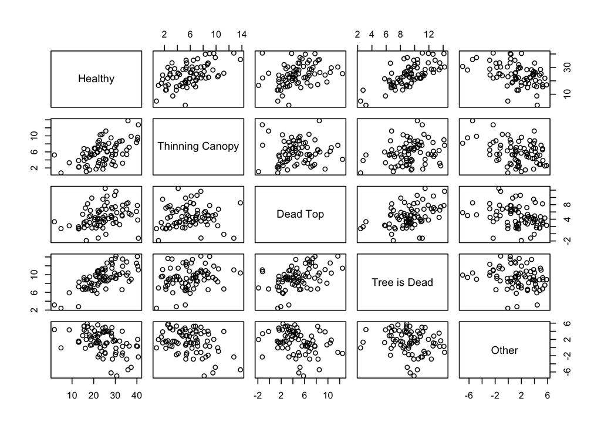